# PANDEMIA DA COVID-19

Como anda a situação do Brasil

Saulo Gil

26 de março de 2021

## **A COVID-19**

Em março de 2020, a Organização Mundial de Saúde (OMS) declarou a síndrome respiratória aguda grave induzida pelo novo coronavírus, doravante COVID-19, como uma pandemia, com números que ultrapassam os **125 milhões de casos confirmados** e mais de **2,7 milhões de mortes** em todo o mundo. Embora a maioria dos pacientes contaminados pela SARS-CoV-2 apresentem sintomas leves (i.e., febre, tosse seca e coriza) e se recuperem completamente em alguns dias, um outro grupo, em particular pacientes idosos e com doenças crônicas (e.g., diabetes tipo 2, hipertensão arterial, obesidade), apresentam desconforto respiratório, evoluem para uma síndrome respiratória aguda grave e, como consequência, necessitam de terapia intensiva com aporte de oxigênio e ventilação mecânica invasiva.

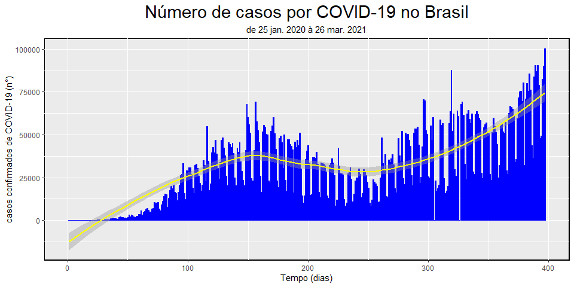

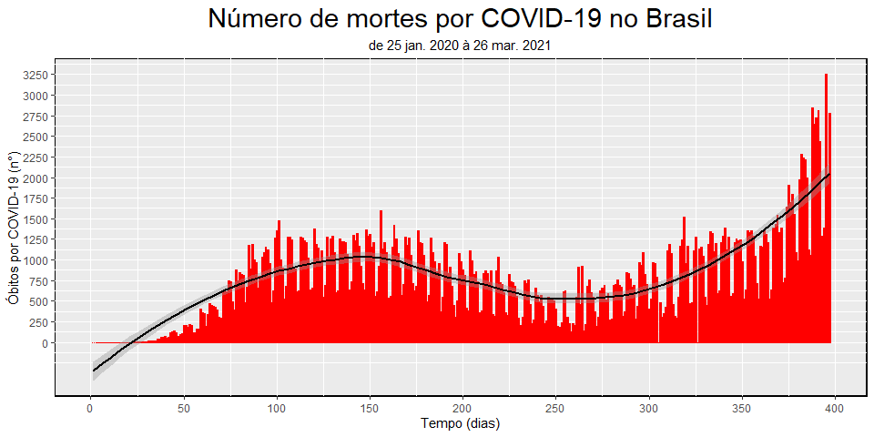

Tabela1. Número total de casos e mortes por COVID-19 por estado

| Estado | Total de casos (n°) | Total de mortes (n°) |
| --- | --- | --- |
| AC | 67,292 | 1,217 |
| AL | 149,697 | 3,421 |
| AM | 343,133 | 11,893 |
| AP | 94,285 | 1,258 |
| BA | 783,558 | 14,631 |
| CE | 516,556 | 13,313 |
| DF | 335,153 | 5,610 |
| ES | 368,402 | 7,161 |
| GO | 467,251 | 10,743 |
| MA | 238,042 | 5,837 |
| MG | 1,067,919 | 22,571 |
| MS | 206,968 | 3,975 |
| MT | 295,805 | 7,039 |
| PA | 406,050 | 10,011 |
| PB | 251,278 | 5,404 |
| PE | 339,022 | 11,853 |
| PI | 197,159 | 3,919 |
| PR | 824,049 | 15,750 |
| RJ | 632,533 | 35,563 |
| RN | 189,479 | 4,309 |
| RO | 180,348 | 3,876 |
| RR | 88,458 | 1,303 |
| RS | 815,172 | 17,941 |
| SC | 786,197 | 10,108 |
| SE | 169,458 | 3,368 |
| SP | 2,370,885 | 69,503 |
| TO | 136,020 | 1,885 |

Com mais de 12.3 milhões de casos e 303 mil mortes, o Brasil apresenta uma situação preocupante uma vez que o país tem quebrado recordes diários de número de casos confirmados e mortes. Conforme observamos na figura acima, pode-se verificar que o Brasil apresenta a tão temida segunda onda de mortes e, neste complicado cenário sanitário, entender a dinâmica dos casos confirmados e mortes por COVID-19 nas diferentes regiões do Brasil podem auxiliar no direcionamento de políticas de saúde pública.

Ao obsevar a Tabela 1 podemos observar um elevado número de pessoas contaminadas e mortes em todos os estados do país. A fim de reforçar a assunção acima descrita e considerando que as cidades com maior número de habitantes podem contribuir na disseminação do vírus em cada uma das regiões do Brasil foi realizada uma análise por inspeção visual dos dados de mortes por COVID-19 das cidades com maior número de habitantes de cada região do país (i.e., Paraná [PR], São Paulo [SP], Goiás [GO], Bahia [BA] e Pará [PR]).

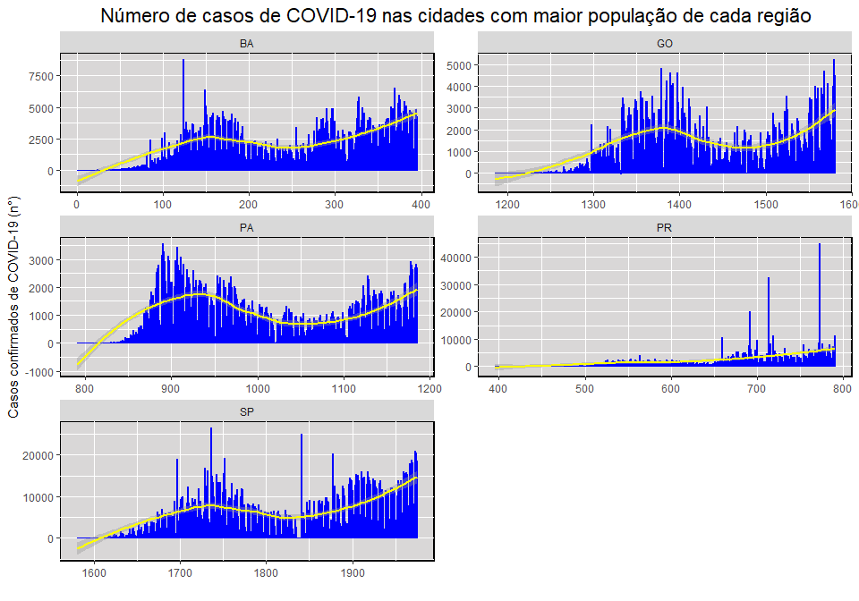

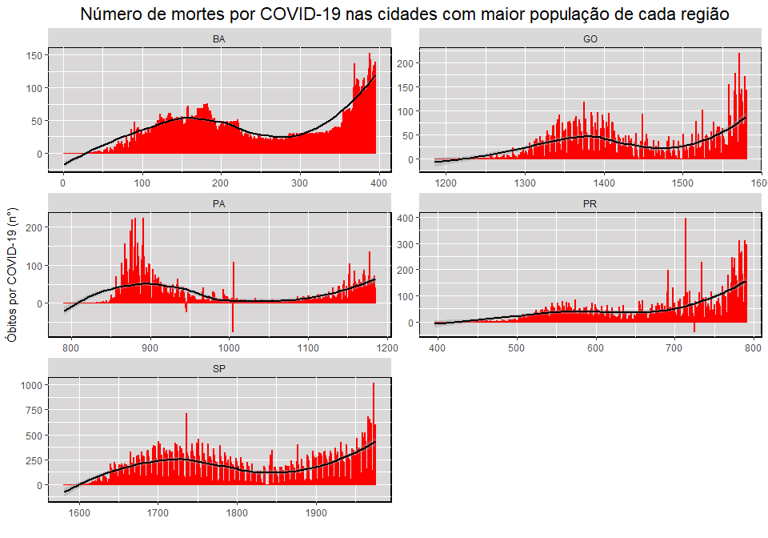

Como podemos observar nas figuras acima, pode-se notar que os estados com maior população em cada uma das regiões do Brasil apresentam um importante aumento no número de casos e mortes por COVID-19, evidenciando a segunda onda de casos e mortes por COVID-19. Vale destacar que dos 5 estados analisados, 4 deles (i.e., Bahia, Goiás, Paraná e São Paulo) apresentam um número de mortes diário superior ao número de mortes observado no primeiro pico de mortes. Esses resultados indicam a atual e grave situação sanitária do país com relação ao controle da pandemia.

Em uma outra perspectiva, foi analisado se o número de casos novos e o número de óbitos novos estão relacionados. Para isso, estes parametros foram plotados em um gráfico de dispersão (figura abaixo). A partir desta analise, é possível verificar um forte correlação (**0.83**) entre o número de casos e mortes por COVID-19, indicando a necessidade de medidas para conter a transmissão do vírus.

Embora a base de dados aqui analisada, não apresente os dados de hospitalização e número de leitos disponiveis para tratamento de pacientes com COVID-19 é razoável assumir que a elevada relação entre número de casos novos e mortes esteja relacionada, também, com o número de hospitalizações visto que o pacientes que vão a óbito, normalmente, são atendidos por algum serviço de saúde. Assim, tendo em vista que o elevado número de pessoas que contraem o virús podem necessitar de assistência médica e hospitalar, é fundamental que pesquisadores e profissionais da saúde involvidos no manejo do pacientes com COVID-19 busquem medidas preditivas do prognóstico destes pacientes.

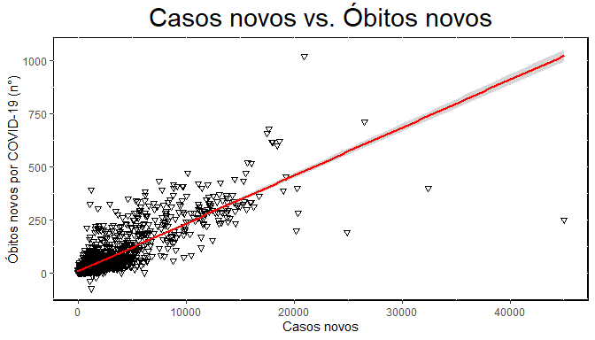

## **BUSCANDO PREDITORES DO TEMPO DE HOSPITALIZAÇÃO DE PACIENTES COM COVID-19**

Além de manter a integridade do sistema esquelético e gerar força para locomoção, é sábido que a musculatura exerce papel fundamental em alguns processos fisiológicos tais como imunidade, regulação dos níveis de glicose, síntese proteica e taxa metabólica basal. Na clínica médica, a avaliação da força muscular é amplamente utilizada como indicador do estado geral de saúde. De fato, a massa muscular e força são preditores independentes de mortalidade em distintas populações, mas ainda não se sabe se a força muscular é uma medida preditiva do tempo de hospitalização de pacientes hospitalizados com SARS-CoV-2.

Pensando nisso, nosso grupo de pesquisa (Fisiologia aplicada e nutrição - FMUSP) avaliou a força muscular de pacientes admitidos no Hospital das Clínicas da Faculdade de Medicina da USP (HCFMUSP) com COVID-19 e acompanhou-os até a alta hospitalar ou óbito. Resumidamente, foram avaliados 196 pacientes dos quais 186 pacientes entraram na análise (10 não testaram positivo para COVID-19). Os pacientes foram ranqueados e estratificados em tercil de acordo com o nível de força muscular avaliado na admissão hospitalar. Para verificar se o nível de força esta associado com o tempo de internação, nós comparamos o 1° tercil (pacientes mais “fortes”) com o demais tercis (2 e 3° tercil, pacientes mais “fraco”). *Quando comparado os estratos (pacientes “fortes” vs. pacientes “fracos”) foi observado um menor tempo de hospitalização nos pacientes fortes em comparação com pacientes mais fracos (pacientes fortes 7±6 dias vs. pacientes mais fracos 9±8 dias). A figura abaixo ilustra a curva de sobrevivência dos pacientes estratificados conforme o nível de força muscular.* A taxa de mortalidade em nossa amostra foi de **6.5%**.

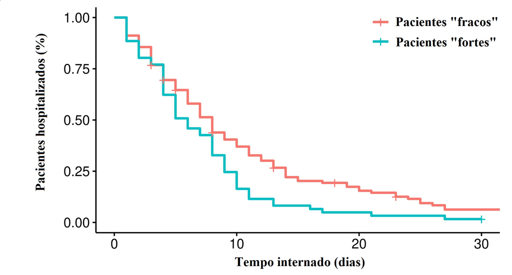

Esses resultados sugerem que a avaliação da força muscular no momento da admissão hospitalar é uma medida preditiva do tempo de hospitalização de pacientes hospitalizados com COVID-19. Esses resultados destacam a importância de políticas de saúde pública que estimulem a prática de exercícios físicos, em particular aqueles que promovem ganhos de força, uma vez que o nível de força muscular pode impactar no prognótico de doenças graves como, por exemplo, a COViD-19.

## **CONSIDERAÇÕES FINAIS**

Como pudemos observar a partir da análise do banco de dados sobre mortes e contaminação por COVID-19 do Ministério da Saúde, o Brasil apresenta um momento preocupante com um claro aumento no número de mortes e, desta maneira, evidenciando a tão temida segunda onda.

Após conduzirmos um estudo com os pacientes hospitalizados com COVID-19 no HCFMUSP, nós identificamos que a força muscular avaliada no momento da admissão hospitalar (uma medida de simples excecução e de baixo-custo) dos pacientes hospitalizados é um preditor do tempo de hospitalização. Esse achado pode auxiliar a tomada de decisão de profissionais de saúde da linha de frente com relação ao prognóstico do paciente hospitalizado com COVID-19.

Por fim, vale ressaltar que mesmo com o início da vacinação e para aqueles que já foram vacinados, as medidas de proteção como higienização e distanciamento social ainda são necessárias. Então, se puder, **FIQUE EM CASA!**

[figure not shown]

## **FONTES**

1. Base de dados: [COVID-BRASIL.GOV](https://covid.saude.gov.br/), acesso 25 de março de 2021.
2. Curva de sobrevivência: Gil, S. et. al. Muscle Strength and Muscle Mass as Predictors of Hospital Length of Stay in Patients with Moderate to Severe COVID-19: A Prospective Observational Study **[artigo em revisão]**